# tSNE vs. UMAP: Global Structure Preservation

#### Nikolay Oskolkov, SciLifeLab, NBIS Long Term Support, nikolay.oskolkov@scilifelab.se

### Abstract

In this notebook, we will discuss the importance of global structure preservation by the tSNE and UMAP neighbor graph algorithms. we will check to what extent both algorithms can preserve global structure of syntetic and real-world scRNAseq data, as well as discuss where this originates mathematically from.

### Table of Contents:

- Global Structure Preservation: Why It Is Important
- What Exactly We Mean By Global Structure Preservation
- Making SciKitLearn tSNE Agree with My Implementation of tSNE
- Checking that Sigma from Leland's Implementation of UMAP Agrees with Mine
- Quantify How Well Dimension Reduction Algorithms Preserve Global Structure
- tSNE Degrades to PCA at Large Perplexity

### Global Structure Preservation: Why It Is Important

If you use tSNE and UMAP only for visulaization of high-dimensional data, you probably have never thought about how much of global structure they can preserve. Indeed, both tSNE and UMAP were designed to predominanlty preserve **local structure** that is to group neigboring data points together which provides very informative visualization.

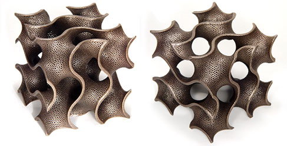

```python
from IPython.display import Image
Image('/home/nikolay/Documents/Medium/tSNE_vs_UMAP/GyroidSculpture.jpg', width=1000)
```

However, if you want to make a next step beyond visualization and run **clustering** you will have difficulty doing it on the original data due to the **Curse of Dimensionality** and the choice of a proper distance metric, instead clustering on tSNE or UMAP reduced dimensions can be more promising. Below, I use scRNAseq data from [Björklund et al.](https://www.ncbi.nlm.nih.gov/pubmed/26878113) Innate Limphoid Cells (ILC) and compare K-means clustering on 1) raw expression data, 2) significant 30 Principal Components (PCs), 3) tSNE 2D representation, and 4) 30 UMAP components. As we can see, due to the Curse of Dimensionality and non-linearity of the scRNAseq data, K-means clustering failed on the raw expression data and the 30 PCs were apparently also too high-dimensional space for K-means to succeed. In contrast, non-linear dimension reduction down to 2 for tSNE and 30 for UMAP resulted in almost perfect agreement between clustering and tSNE dimension reduction.

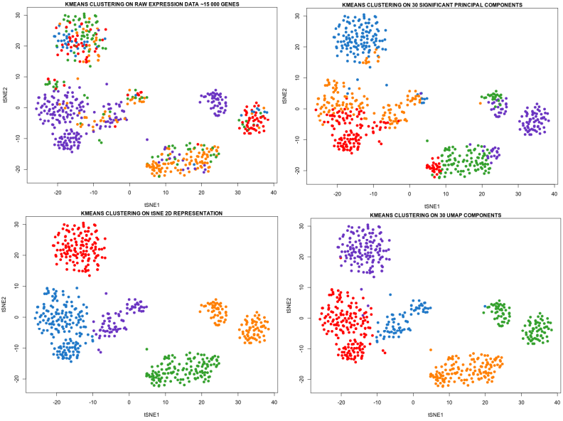

```python
from IPython.display import Image
Image('/home/nikolay/Documents/Medium/tSNE_vs_UMAP/Kmeans_tSNE_SignPCs_RawExpr_UMAPComp.png', width=2000)
```

However, this is where you really want to make sure that the **tSNE and UMAP components capture enough of global structure in the original data**, that is preserve distance between clusters of data points, in order to obtain a **correct hierarchy** between the data points or clusters of data points that were distant in high dimensions. Although not perfectly correct, in layman's terms one can say that:

- **Local structure preservation is important for visualization**
- **Global structure preservation is important for clustering**

It is widely acknowledged that clustering on 2D tSNE representation is not a good idea because the distances between clusters (global structure) are not guaranteed to be preserved, therefore proximity of two clusters on a tSNE plot does not imply a biological similarity between the two cell populations. Clustering on a 2D UMAP representation may be better idea since UMAP preserves more of a global structure, however this is still to be proven. What we definitely see from the plot above is that clustering on a number of UMAP components outperformes clustering on a number of PCs since **30 UMAP components retain more variation in the data than 30 PCs**. In contrast, **tSNE can not deliver more than 3 components** due to technical limitations, so clustering on a number of tSNE components is basically impossible. So clustering - this is where you start seeing the difference between tSNE and UMAP.

### What Exactly We Mean By Global Structure Preservation

Remember that the goal of dimension reduction is to transform the data from high- to low-dimensional space, i.e. represent the cells / samples in low-dimensional space without loosing too much information, i.e. **preserving distances between both close and distant samples / cells**. What exactly do we mean when we say that a dimension reduction algorithm is capable of preserving global structure? Both tSNE and UMAP define the probability to observe points at a certain distance to belong to the following exponential family:

$$p_{ij}\approx \displaystyle e^{\displaystyle -\frac{(x_i-x_j)^2}{2\sigma_i^2}}$$

Here $\sigma_i$ is a parameter responsible for how much cells / samples can "feel" each other. Since $\sigma_i$ is a finite value, i.e. does not go yo infinity, every data point can "feel" the presence only its closest neighbors and not the distant points, therefore both tSNE and UMAP are **neighbor graph** algorithms and hence preserve **local structure** of the data. However, in the limit $\sigma_i \rightarrow \infty$ there is a chance that every point "remembers" every other point, so in this limit **in theory both tSNE and UMAP can preserve global structure**. However, it is not the $\sigma_i$ that the hyperparameter of tSNE and UMAP but the **perplexity** and **number of nearest neigbors n_neigbors**, respectively. Let us check what perplexity and n_neighbors values lead to the limit $\sigma_i \rightarrow \infty$. For this purpose we will take one syntetic and one real-world scRNAseq data sets and compute how mean $\sigma$ depend on the perplexity and n_neighbors.

To check how much PCA / MDS, tSNE and UMAP are capable of preserving global structure, let us contruct a syntetic data set representing the world map with 5 continents: Eurasia, Africa, North America, South America and Australia. We sample a few thousand points from the areas of the continents and will use them for testing the dimension reduction techniques.

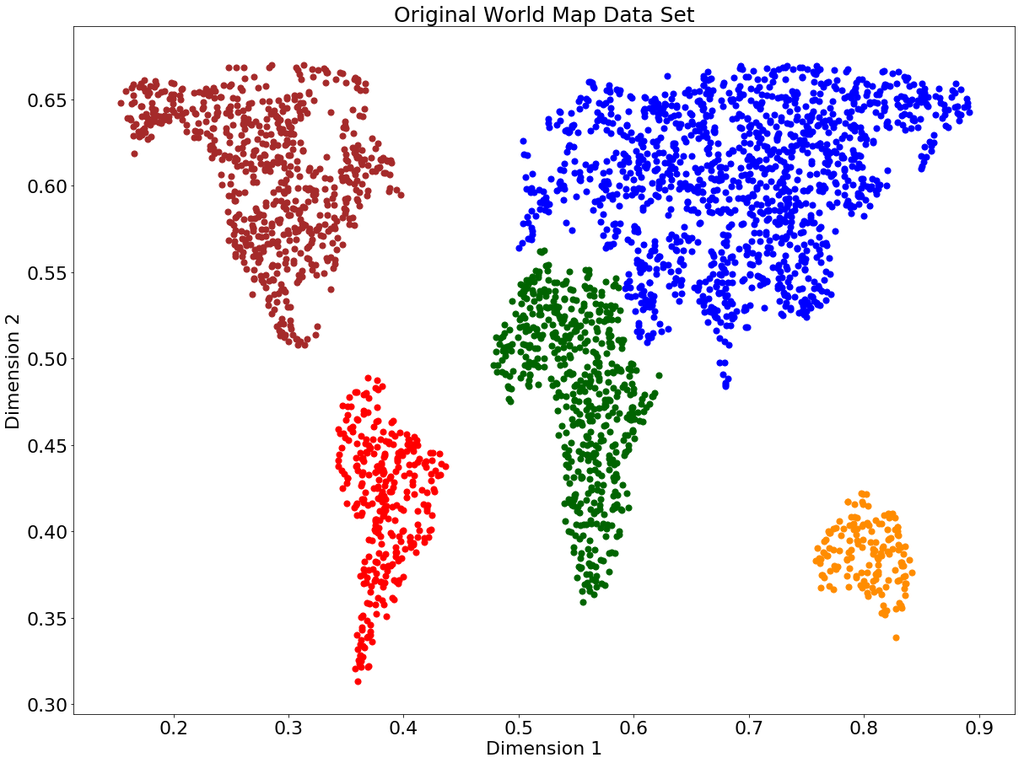

```python
import cartopy
import matplotlib
import numpy as np
import cartopy.crs as ccrs
import matplotlib.pyplot as plt
import cartopy.feature as cfeature
from skimage.io import imread
import cartopy.io.shapereader as shpreader

shapename = 'admin_0_countries'
countries_shp = shpreader.natural_earth(resolution='110m',
                                        category='cultural', name=shapename)

plt.figure(figsize = (20, 15))
ax = plt.axes(projection=ccrs.Miller())
ax.outline_patch.set_visible(False)
ax.set_extent([-180, 180, -50, 70])
for country in shpreader.Reader(countries_shp).records():
    #print(country.attributes['NAME_LONG'])
    if country.attributes['NAME_LONG'] in ['United States','Canada', 'Mexico']:
        ax.add_geometries(country.geometry, ccrs.Miller(),
                          label=country.attributes['NAME_LONG'], color = 'black')
        plt.savefig('NorthAmerica.png')
plt.close()

plt.figure(figsize = (20, 15))
ax = plt.axes(projection=ccrs.Miller())
ax.outline_patch.set_visible(False)
ax.set_extent([-180, 180, -50, 70])
for country in shpreader.Reader(countries_shp).records():
    if country.attributes['NAME_LONG'] in ['Brazil','Argentina', 'Peru', 'Uruguay', 'Venezuela',
                                           'Columbia', 'Bolivia', 'Colombia', 'Ecuador', 'Paraguay']:
        ax.add_geometries(country.geometry, ccrs.Miller(),
                          label=country.attributes['NAME_LONG'], color = 'black')
        plt.savefig('SouthAmerica.png')
plt.close()

plt.figure(figsize = (20, 15))
ax = plt.axes(projection=ccrs.Miller())
ax.outline_patch.set_visible(False)
ax.set_extent([-180, 180, -50, 70])
for country in shpreader.Reader(countries_shp).records():
    if country.attributes['NAME_LONG'] in ['Australia']:
        ax.add_geometries(country.geometry, ccrs.Miller(),
                          label=country.attributes['NAME_LONG'], color = 'black')
        plt.savefig('Australia.png')
plt.close()


plt.figure(figsize = (20, 15))
ax = plt.axes(projection=ccrs.Miller())
ax.outline_patch.set_visible(False)
ax.set_extent([-180, 180, -50, 70])
for country in shpreader.Reader(countries_shp).records():
    if country.attributes['NAME_LONG'] in ['Russian Federation', 'China', 'India', 'Kazakhstan', 'Mongolia',
                                          'France', 'Germany', 'Spain', 'Ukraine', 'Turkey', 'Sweden',
                                           'Finland', 'Denmark', 'Greece', 'Poland', 'Belarus', 'Norway',
                                           'Italy', 'Iran', 'Pakistan', 'Afganistan', 'Iraq', 'Bulgaria',
                                           'Romania', 'Turkmenistan', 'Uzbekistan' 'Austria', 'Ireland',
                                           'United Kingdom', 'Saudi Arabia', 'Hungary']:
        ax.add_geometries(country.geometry, ccrs.Miller(),
                          label=country.attributes['NAME_LONG'], color = 'black')
        plt.savefig('Eurasia.png')
plt.close()


plt.figure(figsize = (20, 15))
ax = plt.axes(projection=ccrs.Miller())
ax.outline_patch.set_visible(False)
ax.set_extent([-180, 180, -50, 70])
for country in shpreader.Reader(countries_shp).records():
    if country.attributes['NAME_LONG'] in ['Libya', 'Algeria', 'Niger', 'Marocco', 'Egypt', 'Sudan', 'Chad',
                                           'Democratic Republic of the Congo', 'Somalia', 'Kenya', 'Ethiopia',
                                           'The Gambia', 'Nigeria', 'Cameroon', 'Ghana', 'Guinea', 'Guinea-Bissau',
                                           'Liberia', 'Sierra Leone', 'Burkina Faso', 'Central African Republic',
                                           'Republic of the Congo', 'Gabon', 'Equatorial Guinea', 'Zambia',
                                           'Malawi', 'Mozambique', 'Angola', 'Burundi', 'South Africa',
                                           'South Sudan', 'Somaliland', 'Uganda', 'Rwanda', 'Zimbabwe', 'Tanzania',
                                           'Botswana', 'Namibia', 'Senegal', 'Mali', 'Mauritania', 'Benin',
                                           'Nigeria', 'Cameroon']:
        ax.add_geometries(country.geometry, ccrs.Miller(),
                          label=country.attributes['NAME_LONG'], color = 'black')
        plt.savefig('Africa.png')
plt.close()


rng = np.random.RandomState(123)
plt.figure(figsize = (20, 15))
matplotlib.rcParams.update({'font.size': 22})


N_NorthAmerica = 10000
data_NorthAmerica = imread('NorthAmerica.png')[::-1, :, 0].T
X_NorthAmerica = rng.rand(4 * N_NorthAmerica, 2)
i, j = (X_NorthAmerica * data_NorthAmerica.shape).astype(int).T
X_NorthAmerica = X_NorthAmerica[data_NorthAmerica[i, j] < 1]
X_NorthAmerica = X_NorthAmerica[X_NorthAmerica[:, 1]<0.67]
y_NorthAmerica = np.array(['brown']*X_NorthAmerica.shape[0])
plt.scatter(X_NorthAmerica[:, 0], X_NorthAmerica[:, 1], c = 'brown', s = 50)

N_SouthAmerica = 10000
data_SouthAmerica = imread('SouthAmerica.png')[::-1, :, 0].T
X_SouthAmerica = rng.rand(4 * N_SouthAmerica, 2)
i, j = (X_SouthAmerica * data_SouthAmerica.shape).astype(int).T
X_SouthAmerica = X_SouthAmerica[data_SouthAmerica[i, j] < 1]
y_SouthAmerica = np.array(['red']*X_SouthAmerica.shape[0])
plt.scatter(X_SouthAmerica[:, 0], X_SouthAmerica[:, 1], c = 'red', s = 50)

N_Australia = 10000
data_Australia = imread('Australia.png')[::-1, :, 0].T
X_Australia = rng.rand(4 * N_Australia, 2)
i, j = (X_Australia * data_Australia.shape).astype(int).T
X_Australia = X_Australia[data_Australia[i, j] < 1]
y_Australia = np.array(['darkorange']*X_Australia.shape[0])
plt.scatter(X_Australia[:, 0], X_Australia[:, 1], c = 'darkorange', s = 50)

N_Eurasia = 10000
data_Eurasia = imread('Eurasia.png')[::-1, :, 0].T
X_Eurasia = rng.rand(4 * N_Eurasia, 2)
i, j = (X_Eurasia * data_Eurasia.shape).astype(int).T
X_Eurasia = X_Eurasia[data_Eurasia[i, j] < 1]
X_Eurasia = X_Eurasia[X_Eurasia[:, 0]>0.5]
X_Eurasia = X_Eurasia[X_Eurasia[:, 1]<0.67]
y_Eurasia = np.array(['blue']*X_Eurasia.shape[0])
plt.scatter(X_Eurasia[:, 0], X_Eurasia[:, 1], c = 'blue', s = 50)

N_Africa = 10000
data_Africa = imread('Africa.png')[::-1, :, 0].T
X_Africa = rng.rand(4 * N_Africa, 2)
i, j = (X_Africa * data_Africa.shape).astype(int).T
X_Africa = X_Africa[data_Africa[i, j] < 1]
y_Africa = np.array(['darkgreen']*X_Africa.shape[0])
plt.scatter(X_Africa[:, 0], X_Africa[:, 1], c = 'darkgreen', s = 50)

plt.title('Original World Map Data Set', fontsize = 25)
plt.xlabel('Dimension 1', fontsize = 22); plt.ylabel('Dimension 2', fontsize = 22)

plt.show()
```

As a result we have a collection of 2D data points belonging to 5 clusters / continents. So far this is planar linear geometry, therefore linear dimensionality reduction techniques should be able to reconstruct the original data.

```python
X = np.vstack((X_NorthAmerica, X_SouthAmerica, X_Australia, X_Eurasia, X_Africa))
y = np.concatenate((y_NorthAmerica, y_SouthAmerica, y_Australia, y_Eurasia, y_Africa))
print(X.shape)
print(y.shape)
```

```
(3023, 2)
(3023,)
```

We will start with linear dimensiona reduction techniques: PCA and MDS that can perfectly preserve global distances.

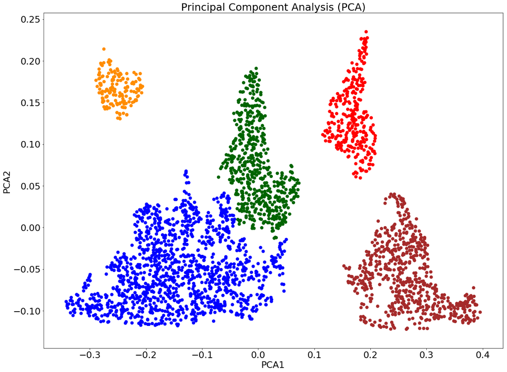

```python
from sklearn.decomposition import PCA
X_reduced = PCA(n_components = 2).fit_transform(X)
plt.figure(figsize=(20,15))
plt.scatter(X_reduced[:, 0], X_reduced[:, 1], c = y, s = 50)
plt.title('Principal Component Analysis (PCA)', fontsize = 25)
plt.xlabel("PCA1", fontsize = 22)
plt.ylabel("PCA2", fontsize = 22)
plt.show()
```

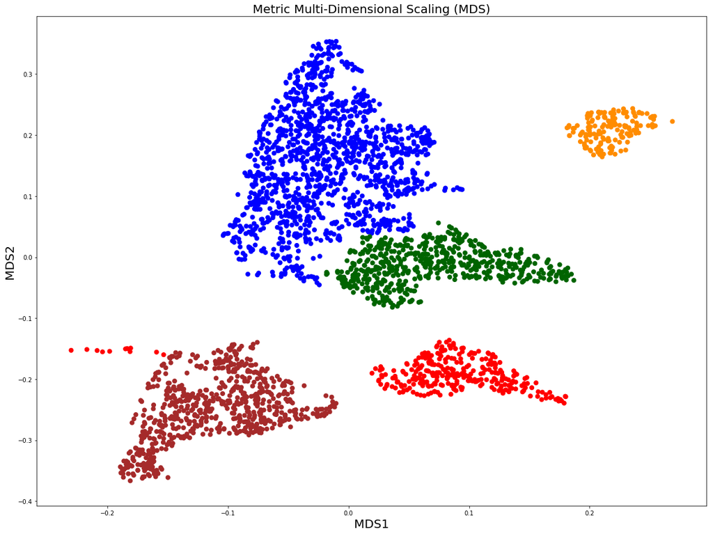

```python
from sklearn.manifold import MDS
model_mds = MDS(n_components = 2, random_state = 123, metric = True)
mmds = model_mds.fit_transform(X)
plt.figure(figsize=(20,15))
plt.scatter(mmds[:, 0], mmds[:, 1], c = y, s = 50)
plt.title('Metric Multi-Dimensional Scaling (MDS)', fontsize = 20)
plt.xlabel("MDS1", fontsize = 20); plt.ylabel("MDS2", fontsize = 20)
plt.show()
```

We confirm that up to linear transformations such as flip, shift and rotation, the original data set is very well reconstructed by the PCA and MDS linear dimension reduction techniques. Let us now check how non-linear dimensiona reduction techniques such as tSNE and UMAP perform on the 2D linear data. We deliberately select large perplexity and n_neighbors hyperparameters that should result in $\sigma_i \rightarrow \infty$ and therefore better preservation of the global structure.

```
[t-SNE] Computing 1501 nearest neighbors...
[t-SNE] Indexed 3023 samples in 0.001s...
[t-SNE] Computed neighbors for 3023 samples in 0.674s...
[t-SNE] Computed conditional probabilities for sample 1000 / 3023
[t-SNE] Computed conditional probabilities for sample 2000 / 3023
[t-SNE] Computed conditional probabilities for sample 3000 / 3023
[t-SNE] Computed conditional probabilities for sample 3023 / 3023
[t-SNE] Mean sigma: 0.060978
[t-SNE] Computed conditional probabilities in 2.641s
[t-SNE] Iteration 50: error = 43.8401680, gradient norm = 0.0025554 (50 iterations in 2.953s)
[t-SNE] Iteration 100: error = 43.6828728, gradient norm = 0.0001747 (50 iterations in 2.801s)
[t-SNE] Iteration 150: error = 43.6869354, gradient norm = 0.0002149 (50 iterations in 2.696s)
[t-SNE] Iteration 200: error = 43.6884346, gradient norm = 0.0004383 (50 iterations in 2.573s)
[t-SNE] Iteration 250: error = 43.6885376, gradient norm = 0.0001415 (50 iterations in 2.606s)
[t-SNE] KL divergence after 250 iterations with early exaggeration: 43.688538
[t-SNE] Iteration 300: error = 0.1987910, gradient norm = 0.0011702 (50 iterations in 2.674s)
[t-SNE] Iteration 350: error = 0.1548541, gradient norm = 0.0001670 (50 iterations in 2.829s)
[t-SNE] Iteration 400: error = 0.1482517, gradient norm = 0.0000505 (50 iterations in 2.858s)
[t-SNE] Iteration 450: error = 0.1469540, gradient norm = 0.0000291 (50 iterations in 2.983s)
[t-SNE] Iteration 500: error = 0.1465182, gradient norm = 0.0000220 (50 iterations in 2.913s)
[t-SNE] Iteration 550: error = 0.1463438, gradient norm = 0.0000148 (50 iterations in 2.902s)
[t-SNE] Iteration 600: error = 0.1462867, gradient norm = 0.0000125 (50 iterations in 2.904s)
[t-SNE] Iteration 650: error = 0.1462306, gradient norm = 0.0000110 (50 iterations in 4.097s)
[t-SNE] Iteration 700: error = 0.1461740, gradient norm = 0.0000088 (50 iterations in 3.267s)
[t-SNE] Iteration 750: error = 0.1461396, gradient norm = 0.0000078 (50 iterations in 2.887s)
[t-SNE] Iteration 800: error = 0.1461195, gradient norm = 0.0000079 (50 iterations in 2.925s)
[t-SNE] Iteration 850: error = 0.1460714, gradient norm = 0.0000074 (50 iterations in 2.897s)
[t-SNE] Iteration 900: error = 0.1460554, gradient norm = 0.0000064 (50 iterations in 5.802s)
[t-SNE] Iteration 950: error = 0.1460518, gradient norm = 0.0000067 (50 iterations in 3.812s)
[t-SNE] Iteration 1000: error = 0.1461060, gradient norm = 0.0000065 (50 iterations in 3.063s)
[t-SNE] KL divergence after 1000 iterations: 0.146106
```

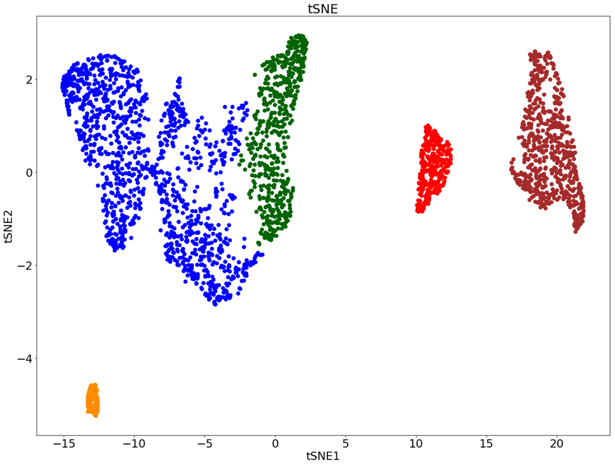

```python
from sklearn.manifold import TSNE
X_reduced = PCA(n_components = 2).fit_transform(X)
model = TSNE(learning_rate = 200, n_components = 2, random_state = 123, perplexity = 500,
             init = X_reduced, n_iter = 1000, verbose = 2)
tsne = model.fit_transform(X)
plt.figure(figsize = (20,15))
plt.scatter(tsne[:, 0], tsne[:, 1], c = y, s = 50)
plt.title('tSNE', fontsize = 25); plt.xlabel("tSNE1", fontsize = 22); plt.ylabel("tSNE2", fontsize = 22)
plt.show()
```

```
UMAP(a=None, angular_rp_forest=False, b=None,
     init=array([[ 0.25580736, -0.08346226],
       [ 0.21164187, -0.0044089 ],
       [ 0.25814581,  0.02748583],
       ...,
       [-0.04541859,  0.06084731],
       [ 0.03837112,  0.01024752],
       [-0.01219052,  0.02886706]]),
     learning_rate=1, local_connectivity=1.0, metric='euclidean',
     metric_kwds=None, min_dist=1, n_components=2, n_epochs=1000,
     n_neighbors=500, negative_sample_rate=5, random_state=None,
     repulsion_strength=1.0, set_op_mix_ratio=1.0, spread=1.0,
     target_metric='categorical', target_metric_kwds=None,
     target_n_neighbors=-1, target_weight=0.5, transform_queue_size=4.0,
     transform_seed=42, verbose=2)
Construct fuzzy simplicial set
Tue Mar  3 17:49:18 2020 Finding Nearest Neighbors
Tue Mar  3 17:49:18 2020 Finished Nearest Neighbor Search
Tue Mar  3 17:49:21 2020 Construct embedding
	completed  0  /  1000 epochs
	completed  100  /  1000 epochs
	completed  200  /  1000 epochs
	completed  300  /  1000 epochs
	completed  400  /  1000 epochs
	completed  500  /  1000 epochs
	completed  600  /  1000 epochs
	completed  700  /  1000 epochs
	completed  800  /  1000 epochs
	completed  900  /  1000 epochs
Tue Mar  3 17:49:52 2020 Finished embedding
```

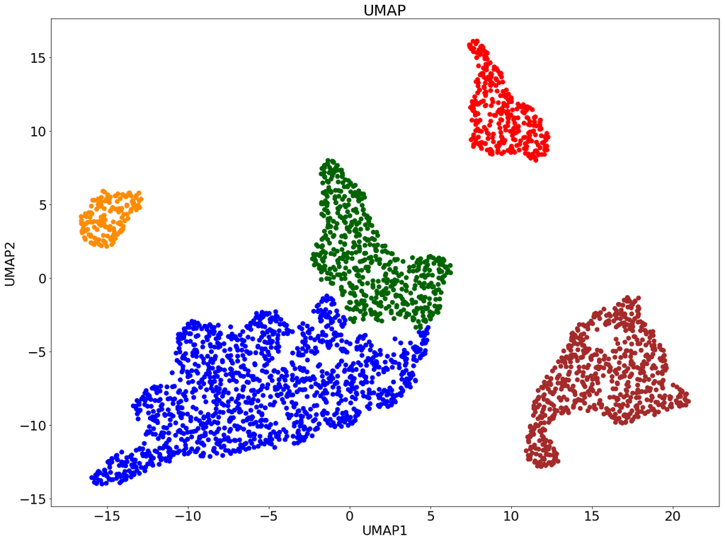

```python
import warnings
warnings.filterwarnings("ignore")

from umap import UMAP
X_reduced = PCA(n_components = 2).fit_transform(X)
model = UMAP(learning_rate = 1, n_components = 2, min_dist = 1, n_neighbors = 500,
             init = X_reduced, n_epochs = 1000, verbose = 2)
umap = model.fit_transform(X)
plt.figure(figsize=(20,15))
plt.scatter(umap[:, 0], umap[:, 1], c = y, s = 50)
plt.title('UMAP', fontsize = 25); plt.xlabel("UMAP1", fontsize = 22); plt.ylabel("UMAP2", fontsize = 22)
plt.show()
```

The quality of visualizations are comparable between tSNE and UMAP in a sense that all the 5 clusters / continents are well distinguishable. However, we can see that the original shapes of the continents are a bit better preserved by UMAP. In addition the South America seems to be placed between Africa and North America by tSNE while it is correctly placed on the same longitude as North America by UMAP.

Previously, it was a 2D data point collection on the linear planar surface. Let us now embedd the 2D data points into the 3D non-linear manifold such as **swiss roll**. Swill roll represents a kind of Archimedean spiral in a 3D space.

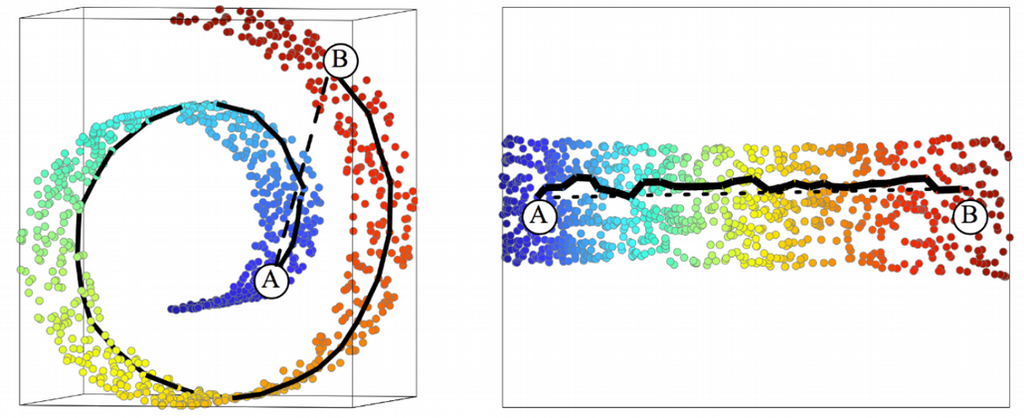

```python
from IPython.display import Image
Image('/home/nikolay/Documents/Medium/tSNE_vs_UMAP/SwissRoll.png', width=2000)
```

When we project our 2D world map onto 3D non-linear manifold, the intrinsic dimensionality of the data is still two even though they points are embedded into 3D space. Therefore linear dimension reduction techniques usually fail reconstructing data on a non-linear manifold as they try to preserve distances between all pairs of points including the ones that are not neighboring on a manifold. Let's project the world map onto the swiss roll.

```python
z_3d = X[:, 1]
x_3d = X[:, 0] * np.cos(X[:, 0]*10)
y_3d = X[:, 0] * np.sin(X[:, 0]*10)

X_swiss_roll = np.array([x_3d, y_3d, z_3d]).T
X_swiss_roll.shape
```

```
(3023, 3)
```

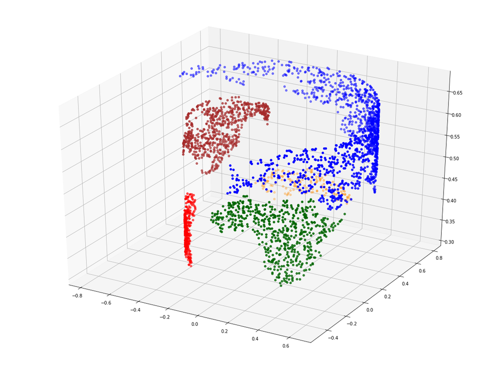

```python
from mpl_toolkits import mplot3d
plt.figure(figsize=(20,15))
ax = plt.axes(projection = '3d')
ax.scatter3D(X_swiss_roll[:, 0], X_swiss_roll[:, 1], X_swiss_roll[:, 2], c = y)
plt.show()
```

First we will check how linear dimension reduction such as PCA and MDS perform on the swiss roll.

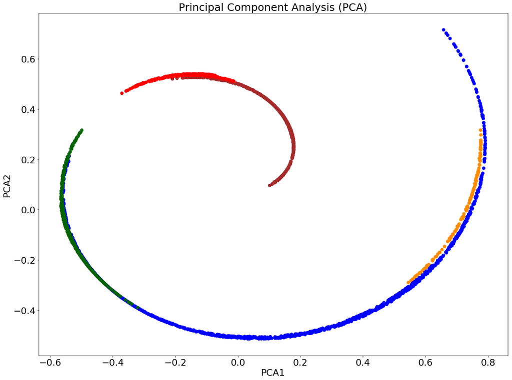

```python
from sklearn.decomposition import PCA
X_swiss_roll_reduced = PCA(n_components = 2).fit_transform(X_swiss_roll)
plt.figure(figsize=(20,15))
plt.scatter(X_swiss_roll_reduced[:, 0], X_swiss_roll_reduced[:, 1], c = y, s = 50)
plt.title('Principal Component Analysis (PCA)', fontsize = 25)
plt.xlabel("PCA1", fontsize = 22); plt.ylabel("PCA2", fontsize = 22)
plt.show()
```

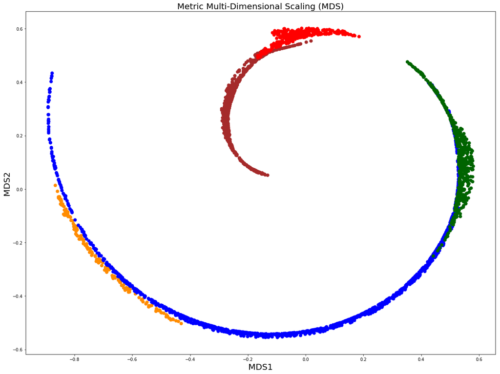

```python
from sklearn.manifold import MDS
model_mds = MDS(n_components = 2, random_state = 123, metric = True)
mds = model_mds.fit_transform(X_swiss_roll)
plt.figure(figsize=(20,15))
plt.scatter(mds[:, 0], mds[:, 1], c = y, s = 50)
plt.title('Metric Multi-Dimensional Scaling (MDS)', fontsize = 20)
plt.xlabel("MDS1", fontsize = 20); plt.ylabel("MDS2", fontsize = 20)
plt.show()
```

As expected both PCA nd MDS fail reconstructing the original data since they try to preserve global distances while for swiss roll it is more important to preserve local neighborhood. Let us now see whether tSNE and UMAP can do it better. Note that **for both tSNE and UMAP we start with PCA as initialization** for the gradient descent algorithm.

```
[t-SNE] Computing 151 nearest neighbors...
[t-SNE] Indexed 3023 samples in 0.003s...
[t-SNE] Computed neighbors for 3023 samples in 0.140s...
[t-SNE] Computed conditional probabilities for sample 1000 / 3023
[t-SNE] Computed conditional probabilities for sample 2000 / 3023
[t-SNE] Computed conditional probabilities for sample 3000 / 3023
[t-SNE] Computed conditional probabilities for sample 3023 / 3023
[t-SNE] Mean sigma: 0.033405
[t-SNE] Computed conditional probabilities in 0.297s
[t-SNE] Iteration 50: error = 56.7442093, gradient norm = 0.0189936 (50 iterations in 0.606s)
[t-SNE] Iteration 100: error = 54.1754074, gradient norm = 0.0130908 (50 iterations in 0.621s)
[t-SNE] Iteration 150: error = 53.1689682, gradient norm = 0.0095972 (50 iterations in 0.603s)
[t-SNE] Iteration 200: error = 52.6251984, gradient norm = 0.0104257 (50 iterations in 0.585s)
[t-SNE] Iteration 250: error = 52.2827072, gradient norm = 0.0080654 (50 iterations in 0.583s)
[t-SNE] KL divergence after 250 iterations with early exaggeration: 52.282707
[t-SNE] Iteration 300: error = 0.7452142, gradient norm = 0.0010242 (50 iterations in 0.595s)
[t-SNE] Iteration 350: error = 0.4960896, gradient norm = 0.0003599 (50 iterations in 0.599s)
[t-SNE] Iteration 400: error = 0.4164004, gradient norm = 0.0002017 (50 iterations in 0.593s)
[t-SNE] Iteration 450: error = 0.3832679, gradient norm = 0.0001595 (50 iterations in 0.584s)
[t-SNE] Iteration 500: error = 0.3684293, gradient norm = 0.0001464 (50 iterations in 0.605s)
[t-SNE] Iteration 550: error = 0.3607625, gradient norm = 0.0001210 (50 iterations in 0.655s)
[t-SNE] Iteration 600: error = 0.3553360, gradient norm = 0.0001125 (50 iterations in 0.630s)
[t-SNE] Iteration 650: error = 0.3510026, gradient norm = 0.0001069 (50 iterations in 0.603s)
[t-SNE] Iteration 700: error = 0.3474116, gradient norm = 0.0000999 (50 iterations in 0.599s)
[t-SNE] Iteration 750: error = 0.3445701, gradient norm = 0.0000983 (50 iterations in 0.595s)
[t-SNE] Iteration 800: error = 0.3423376, gradient norm = 0.0000935 (50 iterations in 0.594s)
[t-SNE] Iteration 850: error = 0.3403157, gradient norm = 0.0000833 (50 iterations in 0.695s)
[t-SNE] Iteration 900: error = 0.3384252, gradient norm = 0.0000810 (50 iterations in 0.604s)
[t-SNE] Iteration 950: error = 0.3368797, gradient norm = 0.0000751 (50 iterations in 0.614s)
[t-SNE] Iteration 1000: error = 0.3352237, gradient norm = 0.0000801 (50 iterations in 0.595s)
[t-SNE] KL divergence after 1000 iterations: 0.335224
```

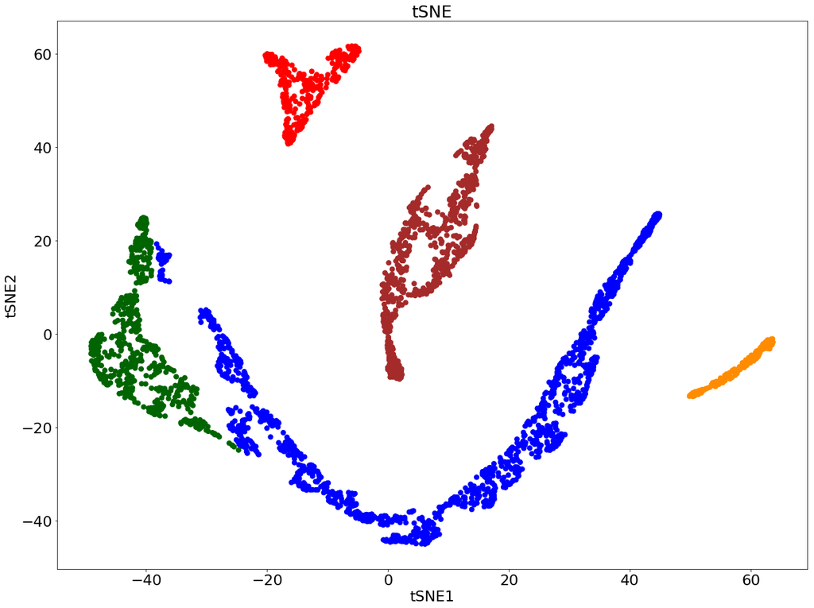

```python
from sklearn.manifold import TSNE
X_swiss_roll_reduced = PCA(n_components = 2).fit_transform(X_swiss_roll)
model = TSNE(learning_rate = 200, n_components = 2, random_state = 123, perplexity = 50,
             init = X_swiss_roll_reduced, n_iter = 1000, verbose = 2)
tsne = model.fit_transform(X_swiss_roll)
plt.figure(figsize=(20,15))
plt.scatter(tsne[:, 0], tsne[:, 1], c = y, s = 50)
plt.title('tSNE', fontsize = 25); plt.xlabel("tSNE1", fontsize = 22); plt.ylabel("tSNE2", fontsize = 22)
plt.show()
```

```
UMAP(a=None, angular_rp_forest=False, b=None,
     init=array([[ 0.12535979,  0.40356518],
       [ 0.00599581,  0.49934623],
       [ 0.12201155,  0.40671414],
       ...,
       [-0.43454162, -0.28447539],
       [-0.55506668,  0.15485573],
       [-0.53099092, -0.11675039]]),
     learning_rate=1, local_connectivity=1.0, metric='euclidean',
     metric_kwds=None, min_dist=1, n_components=2, n_epochs=1000,
     n_neighbors=50, negative_sample_rate=5, random_state=None,
     repulsion_strength=1.0, set_op_mix_ratio=1.0, spread=1.0,
     target_metric='categorical', target_metric_kwds=None,
     target_n_neighbors=-1, target_weight=0.5, transform_queue_size=4.0,
     transform_seed=42, verbose=2)
Construct fuzzy simplicial set
Tue Mar  3 22:15:22 2020 Finding Nearest Neighbors
Tue Mar  3 22:15:23 2020 Finished Nearest Neighbor Search
Tue Mar  3 22:15:23 2020 Construct embedding
	completed  0  /  1000 epochs
	completed  100  /  1000 epochs
	completed  200  /  1000 epochs
	completed  300  /  1000 epochs
	completed  400  /  1000 epochs
	completed  500  /  1000 epochs
	completed  600  /  1000 epochs
	completed  700  /  1000 epochs
	completed  800  /  1000 epochs
	completed  900  /  1000 epochs
Tue Mar  3 22:15:43 2020 Finished embedding
```

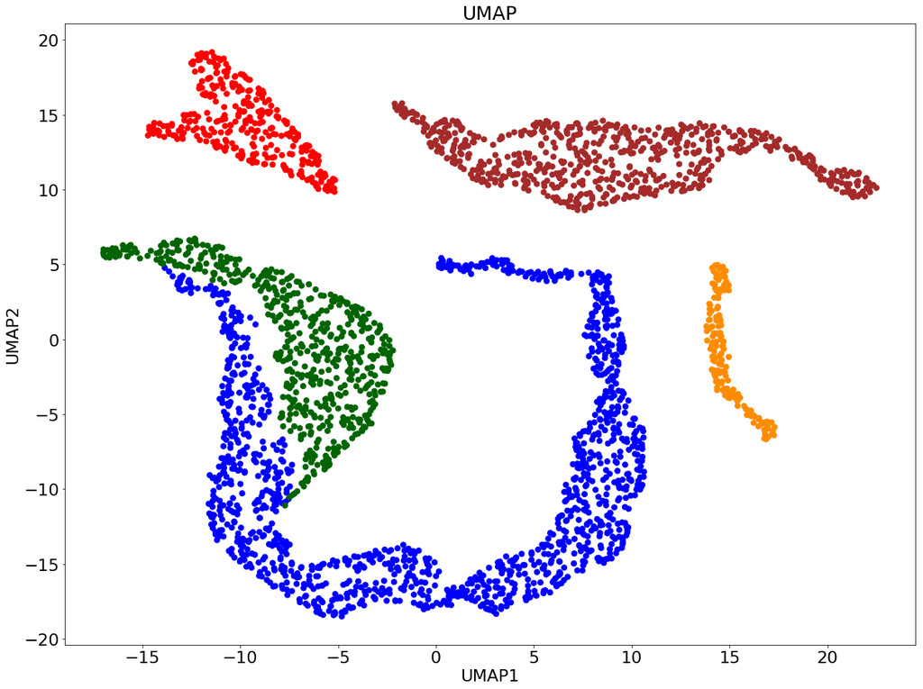

```python
import warnings
warnings.filterwarnings("ignore")

from umap import UMAP
X_swiss_roll_reduced = PCA(n_components = 2).fit_transform(X_swiss_roll)
model = UMAP(learning_rate = 1, n_components = 2, min_dist = 1, n_neighbors = 50,
             init = X_swiss_roll_reduced, n_epochs = 1000, verbose = 2)
umap = model.fit_transform(X_swiss_roll)
plt.figure(figsize=(20,15))
plt.scatter(umap[:, 0], umap[:, 1], c = y, s = 50)
plt.title('UMAP', fontsize = 25); plt.xlabel("UMAP1", fontsize = 22); plt.ylabel("UMAP2", fontsize = 22)
plt.show()
```

A very obvious bug of tSNE that we immediately see is that if one follows the line from South America towards Africa, one passes **Eurasia that was placed by tSNE for some reason between South America and Africa**. In contrast, **UMAP correctly places Africa between South America and Eurasia**.

Obviously, both tSNE and UMAP reconstructed the the original world map better than the PCA and MDS. This is because linear methods such as **PCA and MDS get full affinity matrix as input and try to preserve distances between all pairs of points** while non-linear neigbor graph methods such as **tSNE / UMAP and Locally Linear Embedding (LLE) get sparse affinity matrix (KNN-graph) as input and preserve only distances between nearest neighbors**.

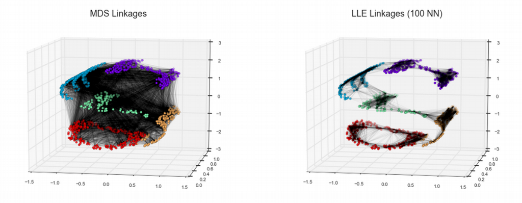

```python
from IPython.display import Image
Image('/home/nikolay/Documents/Medium/tSNE_vs_UMAP/MDS_vs_LLE.png', width=2000)
```

$$y_i = y_i -\mu \frac{\partial \rm{Cost}}{\partial y_i}$$

We see that the final embedding will depend on:

- **initialization (we start wtih random, PCA or Laplacian Eigenmaps coordinates)**
- **internal algorithmic peculiarities that boil down to the cost function, that is Kullback-Leibler (KL) divergence for tSNE and Cross-Entropy (CE) for UMAP**

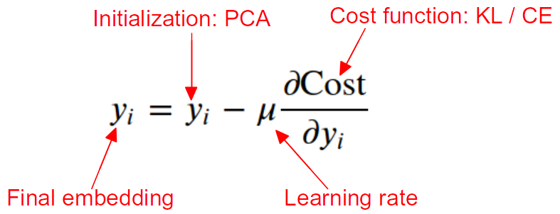

```python
from IPython.display import Image
Image('/home/nikolay/Documents/Medium/tSNE_vs_UMAP/GradDesc.png', width=2000)
```

We are going to compare the two algorithms for their global structure preservation on the world map syntetic data set. People with biological background tend to ignore this approach and prefer to immediately jump to the real-world noisy biological data. However, these simple data sets allow to learn something fundamental about the algorithms, so here we will use more of the good old physics approach.

When we were running PCA / MDS and tSNE / UMAP on 2D linear and 3D non-linear data, we came to opposite conclusions:

- **PCA / MDS perfectly reconstructed the 2D linear data set while performance of tSNE / UMAP was tolarable but worse than PCA /MDS**
- **PCA / MDS totally failed reconstructing 3D non-linear data while performance of tSNE / UMAP was much better**

$$p_{ij}\approx \displaystyle e^{\displaystyle -\frac{(x_i-x_j)^2}{2\sigma_i^2}}$$

```
                1110020A21Rik  1110046J04Rik  1190002F15Rik  1500015A07Rik
SS2_15_0048_A3            0.0            0.0            0.0            0.0
SS2_15_0048_A6            0.0            0.0            0.0            0.0
SS2_15_0048_A5            0.0            0.0            0.0            0.0
SS2_15_0048_A4            0.0            0.0            0.0            0.0

This data set contains 716 samples

Dimensions of the  data set:
(716, 557) (716,)
```

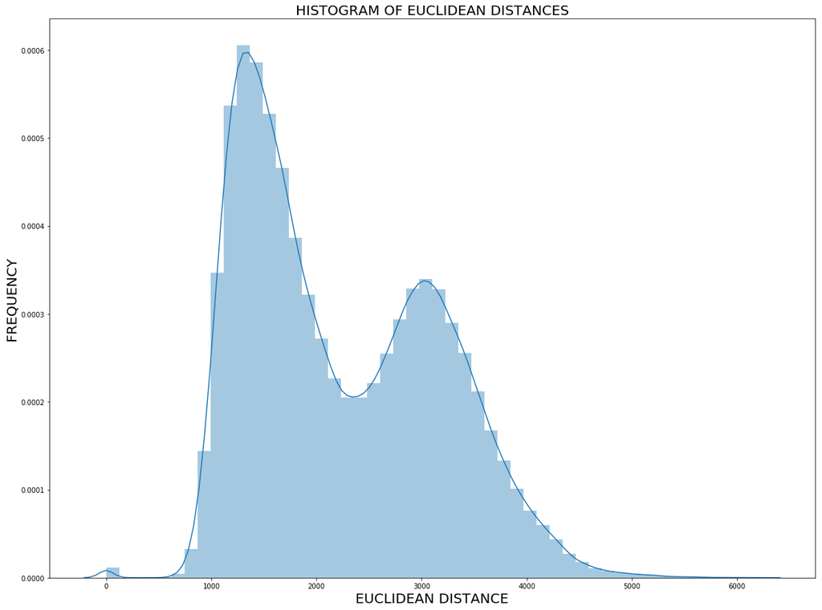

```
Perplexity = 3, Mean Sigma = 3.92004231500892
Perplexity = 13, Mean Sigma = 5.520980451360095
Perplexity = 23, Mean Sigma = 6.091983624676752
Perplexity = 33, Mean Sigma = 6.481132027823166
Perplexity = 43, Mean Sigma = 6.794533916025855
Perplexity = 53, Mean Sigma = 7.0666387760439395
Perplexity = 63, Mean Sigma = 7.312361754518648
Perplexity = 73, Mean Sigma = 7.539448125402354
Perplexity = 83, Mean Sigma = 7.751667299750131
Perplexity = 93, Mean Sigma = 7.95146206903724
Perplexity = 103, Mean Sigma = 8.140649209475384
Perplexity = 113, Mean Sigma = 8.320984227697277
Perplexity = 123, Mean Sigma = 8.493982879809161
Perplexity = 133, Mean Sigma = 8.661166249706758
Perplexity = 143, Mean Sigma = 8.823815670759318
Perplexity = 153, Mean Sigma = 8.982999364757005
Perplexity = 163, Mean Sigma = 9.139716292226781
Perplexity = 173, Mean Sigma = 9.29464441437961
Perplexity = 183, Mean Sigma = 9.448621526110772
Perplexity = 193, Mean Sigma = 9.602192393894303
Perplexity = 203, Mean Sigma = 9.755941742625316
Perplexity = 213, Mean Sigma = 9.910426326304174
Perplexity = 223, Mean Sigma = 10.066091015352217
Perplexity = 233, Mean Sigma = 10.22344461366451
Perplexity = 243, Mean Sigma = 10.382794801083357
Perplexity = 253, Mean Sigma = 10.54484617776711
Perplexity = 263, Mean Sigma = 10.709790544136942
Perplexity = 273, Mean Sigma = 10.878288546088022
Perplexity = 283, Mean Sigma = 11.050645199567912
Perplexity = 293, Mean Sigma = 11.227454553103314
Perplexity = 303, Mean Sigma = 11.409138834010289
Perplexity = 313, Mean Sigma = 11.596250800447091
Perplexity = 323, Mean Sigma = 11.789405812098327
Perplexity = 333, Mean Sigma = 11.989055399122185
Perplexity = 343, Mean Sigma = 12.195846887940135
Perplexity = 353, Mean Sigma = 12.41039031044731
Perplexity = 363, Mean Sigma = 12.633379611223104
Perplexity = 373, Mean Sigma = 12.865303614952046
Perplexity = 383, Mean Sigma = 13.106974809529396
Perplexity = 393, Mean Sigma = 13.358840729271233
```

[output cut: 17 more lines]

```
Perplexity = 573, Mean Sigma = 20.248696790727156
Perplexity = 583, Mean Sigma = 20.837773157897608
Perplexity = 593, Mean Sigma = 21.471276629570475
Perplexity = 603, Mean Sigma = 22.15808330301466
Perplexity = 613, Mean Sigma = 22.909743825816577
Perplexity = 623, Mean Sigma = 23.74180069182838
Perplexity = 633, Mean Sigma = 24.675720896800804
Perplexity = 643, Mean Sigma = 25.741958085385114
Perplexity = 653, Mean Sigma = 26.98616741755821
Perplexity = 663, Mean Sigma = 28.480371283419306
Perplexity = 673, Mean Sigma = 30.348038540206144
Perplexity = 683, Mean Sigma = 32.82577365470332
Perplexity = 693, Mean Sigma = 36.454818768208256
Perplexity = 703, Mean Sigma = 42.95848334967757
Perplexity = 713, Mean Sigma = 68.43397204436404
```

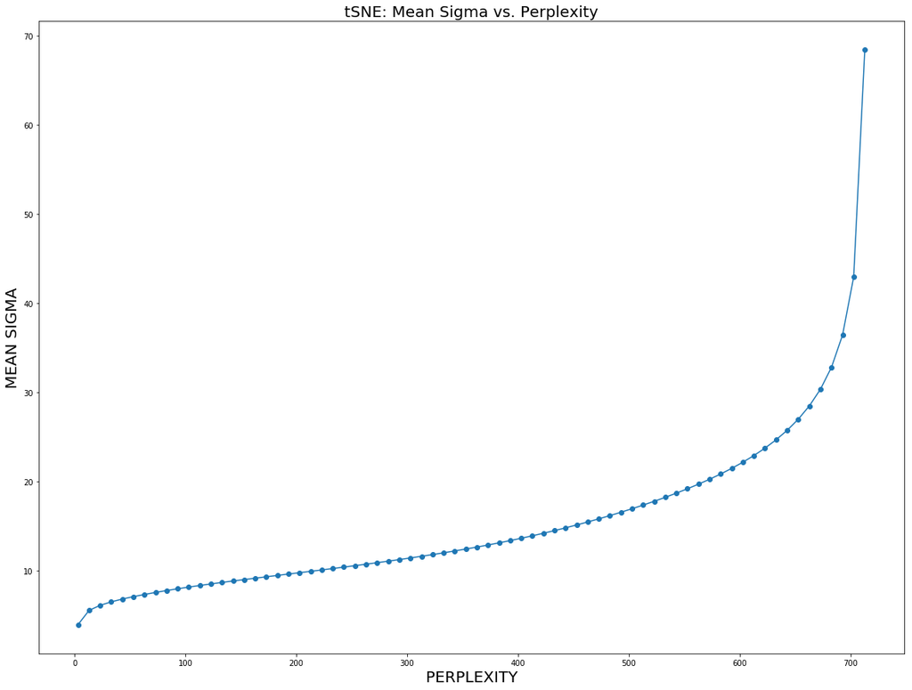

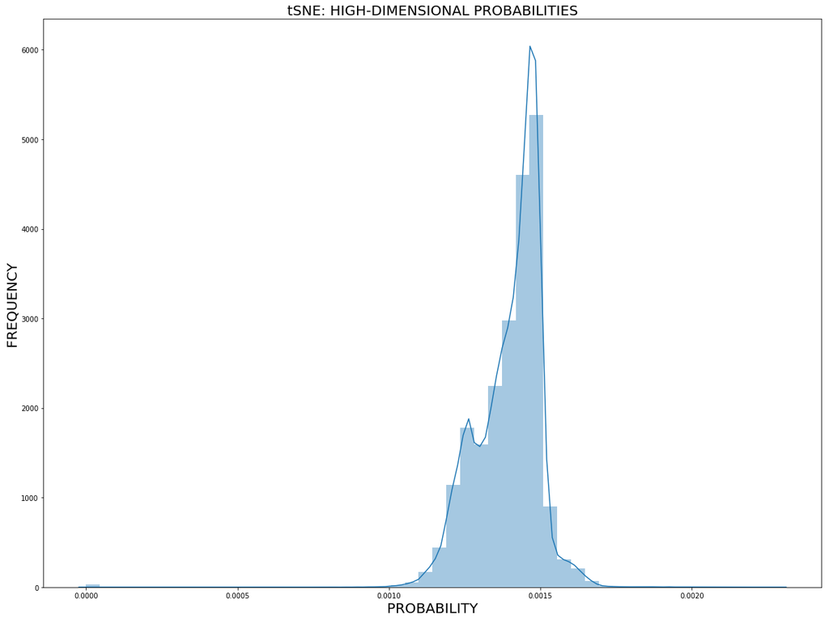

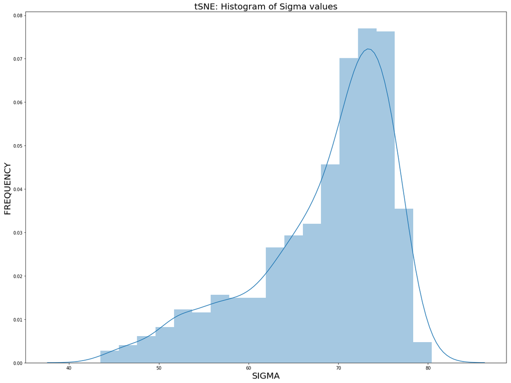

```python
import numpy as np
import pandas as pd
import seaborn as sns
import matplotlib.pyplot as plt
from sklearn.metrics.pairwise import euclidean_distances

import warnings
warnings.filterwarnings("ignore")

#X_train = X;
path = '/home/nikolay/WABI/K_Pietras/Manifold_Learning/'
expr = pd.read_csv(path + 'bartoschek_filtered_expr_rpkm.txt', sep='\t')
print(expr.iloc[0:4,0:4])
X_train = expr.values[:,0:(expr.shape[1]-1)]
X_train = np.log(X_train + 1)
n = X_train.shape[0]
print("\nThis data set contains " + str(n) + " samples")
y_train = expr.values[:,expr.shape[1]-1]
print("\nDimensions of the  data set: ")
print(X_train.shape, y_train.shape)

dist = np.square(euclidean_distances(X_train, X_train))

plt.figure(figsize=(20,15))
sns.distplot(dist.reshape(-1,1))
plt.title("HISTOGRAM OF EUCLIDEAN DISTANCES", fontsize = 20)
plt.xlabel("EUCLIDEAN DISTANCE", fontsize = 20); plt.ylabel("FREQUENCY", fontsize = 20)
plt.show()

def prob_high_dim(sigma, dist_row):
        exp_distance = np.exp(-dist[dist_row] / (2*sigma**2))
        exp_distance[dist_row] = 0
        prob_not_symmetr = exp_distance / np.sum(exp_distance)
        return prob_not_symmetr

def perplexity(prob):
    return np.power(2, -np.sum([p*np.log2(p) for p in prob if p!=0]))

def sigma_binary_search(perp_of_sigma, fixed_perplexity):
    sigma_lower_limit = 0; sigma_upper_limit = 1000
    for i in range(20):
        approx_sigma = (sigma_lower_limit + sigma_upper_limit) / 2
        if perp_of_sigma(approx_sigma) < fixed_perplexity:
            sigma_lower_limit = approx_sigma
        else:
            sigma_upper_limit = approx_sigma
        if np.abs(fixed_perplexity - perp_of_sigma(approx_sigma)) <= 1e-5:
            break
    return approx_sigma

my_perp = []; my_sigma_tSNE = []
for PERPLEXITY in range(3, X_train.shape[0], 10):

    prob = np.zeros((n,n)); sigma_array = []
    for dist_row in range(n):
        func = lambda sigma: perplexity(prob_high_dim(sigma, dist_row))
        binary_search_result = sigma_binary_search(func, PERPLEXITY)
        prob[dist_row] = prob_high_dim(binary_search_result, dist_row)
        sigma_array.append(binary_search_result)

    print("Perplexity = {0}, Mean Sigma = {1}".format(PERPLEXITY, np.mean(sigma_array)))

    my_perp.append(PERPLEXITY)
    my_sigma_tSNE.append(np.mean(sigma_array))

plt.figure(figsize=(20,15))
plt.plot(my_perp, my_sigma_tSNE, '-o')
plt.title("tSNE: Mean Sigma vs. Perplexity", fontsize = 20)
plt.xlabel("PERPLEXITY", fontsize = 20); plt.ylabel("MEAN SIGMA", fontsize = 20)
plt.show()

plt.figure(figsize=(20,15))
sns.distplot(prob.reshape(-1,1))
plt.title("tSNE: HIGH-DIMENSIONAL PROBABILITIES", fontsize = 20)
plt.xlabel("PROBABILITY", fontsize = 20); plt.ylabel("FREQUENCY", fontsize = 20)
plt.show()

plt.figure(figsize=(20,15))
sns.distplot(sigma_array)
plt.title("tSNE: Histogram of Sigma values", fontsize = 20)
plt.xlabel("SIGMA", fontsize = 20)
plt.ylabel("FREQUENCY", fontsize = 20)
plt.show()
```

We can immediately see that at small perplexity the "memory" parameter $\sigma_i$ grows approximetely linearly with perplexity. However, when perplexity approaches the sample size N, the "memory" parameter $\sigma_i$ hyperbolically goes to infinity. We can approximate the behavior of $\sigma_i$ as a function of perplexity with the following simple assymptotic:

$$\sigma (\rm{Perp}) \approx \frac{\rm{Perp} / N}{1 - \rm{Perp} / N}$$

Let us check how well this assymptotic describes the obtained function $\sigma (\rm{Perp})$:

```
[  0.87962035 111.68423252  26.71340589]
```

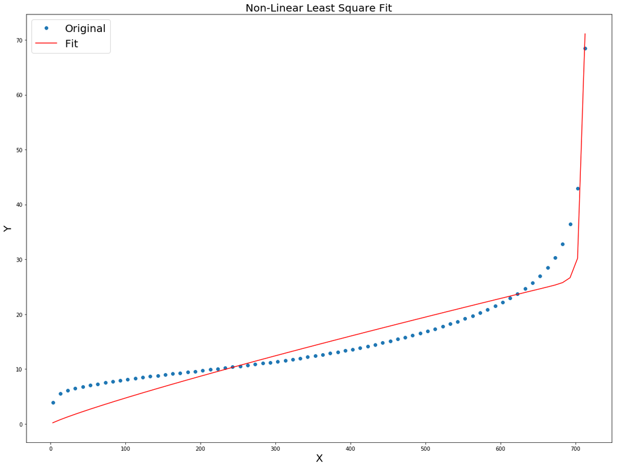

```python
from scipy import optimize
import matplotlib.pyplot as plt
import numpy as np

N = X_train.shape[0]

perp = np.array(my_perp)
sigma_exact = np.array(my_sigma_tSNE)

sigma = lambda perp, a, b, c: (c*(perp / N)**a) / (1 - (perp / N)**b)

p , _ = optimize.curve_fit(sigma, perp, sigma_exact)
print(p)

plt.figure(figsize=(20,15))
plt.plot(perp, sigma_exact, "o")
plt.plot(perp, sigma(perp, p[0], p[1], p[2]), c = "red")
plt.title("Non-Linear Least Square Fit", fontsize = 20)
plt.gca().legend(('Original', 'Fit'), fontsize = 20)
plt.xlabel("X", fontsize = 20); plt.ylabel("Y", fontsize = 20)
plt.show()
```

The fact the parameter $\sigma$ can in principal go to infinity at large perplexity means in practice that the contribution to the gradient descent from the cost function disappears and tSNE becomes heavily dominated by its initialization at large perplexities. Let us prove it from the functional form of the tSNE gradient of the cost function.

Both tSNE and UMAP start with an initialization (random, PCA or Laplacian Eigenmaps) and update the coordinates via the gradient descent algorithm. Here I will ignore normalization constants in the equations of probabilities:

$$y_i = y_i -\mu \frac{\partial KL}{\partial y_i}; \quad \frac{\partial KL}{\partial y_i} = 4\sum_j{(p_{ij}-q_{ij})(y_i-y_j)\frac{1}{1+(y_i-y_j)^2}}; \quad q_{ij}\approx \frac{1}{1+(y_i-y_j)^2}; \quad p_{ij}\approx \displaystyle e^{\displaystyle -\frac{(x_i-x_j)^2}{2\sigma_i^2}}$$

In the limit $\sigma_i \rightarrow \infty$ the probability to observe points at a distance in high-dimensional space becomes $p_{ij} \rightarrow 1$. Therefore:

$$\frac{\partial KL}{\partial y_i} \approx 4\sum_j{\left(1-\frac{1}{1+(y_i-y_j)^2}\right)(y_i-y_j)\frac{1}{1+(y_i-y_j)^2}} = 4\sum_j{\frac{(y_i-y_j)^3}{(1+(y_i-y_j)^2)^2}}$$

In the limit of close embedding points: $$y_i-y_j \rightarrow 0: \quad \frac{\partial KL}{\partial y_i} \approx 4\sum_i{(y_i-y_j)^3} \rightarrow 0$$ In the limit of distant embedding points: $$y_i-y_j \rightarrow \infty: \quad \frac{\partial KL}{\partial y_i} \approx 4\sum_i{\frac{1}{y_i-y_j}} \rightarrow 0$$

We conclude that the contribution to the gradient descent updating rule from the cost function, $\displaystyle\mu\frac{\partial KL}{\partial y_i}$, disappears and therefore if one starts with PCA as an initialization step one ends up with the PCA at the end as initial positions of the points are not getting updated by the gradient descent.

Let us now compute the $\sigma(\rm{n\_neighbor})$ dependence for UMAP and compare it to tSNE:

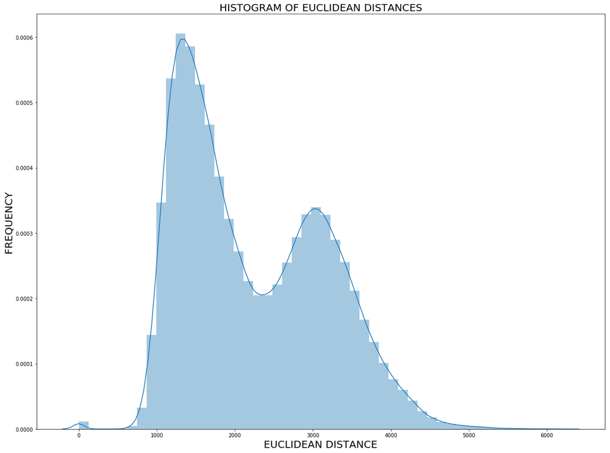

```
N_neighbor = 3, Mean Sigma = 0.00095367431640625
N_neighbor = 13, Mean Sigma = 60.18894211540009
N_neighbor = 23, Mean Sigma = 72.26585143105278
N_neighbor = 33, Mean Sigma = 78.65388300165783
N_neighbor = 43, Mean Sigma = 82.91104119583215
N_neighbor = 53, Mean Sigma = 86.05896161255224
N_neighbor = 63, Mean Sigma = 88.53755450115524
N_neighbor = 73, Mean Sigma = 90.57147942441802
N_neighbor = 83, Mean Sigma = 92.28989531873991
N_neighbor = 93, Mean Sigma = 93.77371931875219
N_neighbor = 103, Mean Sigma = 95.07648372117367
N_neighbor = 113, Mean Sigma = 96.23584667397611
N_neighbor = 123, Mean Sigma = 97.27877611554534
N_neighbor = 133, Mean Sigma = 98.22561088221033
N_neighbor = 143, Mean Sigma = 99.0917163188231
N_neighbor = 153, Mean Sigma = 99.88931437444421
N_neighbor = 163, Mean Sigma = 100.62791781718505
N_neighbor = 173, Mean Sigma = 101.3152372903664
N_neighbor = 183, Mean Sigma = 101.95771009562402
N_neighbor = 193, Mean Sigma = 102.56053349159284
N_neighbor = 203, Mean Sigma = 103.12805229059144
N_neighbor = 213, Mean Sigma = 103.66415711088554
N_neighbor = 223, Mean Sigma = 104.17187280495074
N_neighbor = 233, Mean Sigma = 104.6539418524204
N_neighbor = 243, Mean Sigma = 105.11270981261184
N_neighbor = 253, Mean Sigma = 105.55032245273696
N_neighbor = 263, Mean Sigma = 105.96843005558632
N_neighbor = 273, Mean Sigma = 106.3687801361084
N_neighbor = 283, Mean Sigma = 106.75261939704085
N_neighbor = 293, Mean Sigma = 107.12125447875295
N_neighbor = 303, Mean Sigma = 107.47582419624541
N_neighbor = 313, Mean Sigma = 107.81723160983464
N_neighbor = 323, Mean Sigma = 108.14648633562653
N_neighbor = 333, Mean Sigma = 108.46436090309527
N_neighbor = 343, Mean Sigma = 108.77148798724127
N_neighbor = 353, Mean Sigma = 109.06863345780187
N_neighbor = 363, Mean Sigma = 109.35646195651432
N_neighbor = 373, Mean Sigma = 109.63532644943152
N_neighbor = 383, Mean Sigma = 109.90591422139599
N_neighbor = 393, Mean Sigma = 110.16860354546063
```

[output cut: 17 more lines]

```
N_neighbor = 573, Mean Sigma = 113.91572845714718
N_neighbor = 583, Mean Sigma = 114.08359112020311
N_neighbor = 593, Mean Sigma = 114.24823313452012
N_neighbor = 603, Mean Sigma = 114.40984230467727
N_neighbor = 613, Mean Sigma = 114.56845725714827
N_neighbor = 623, Mean Sigma = 114.72423649367008
N_neighbor = 633, Mean Sigma = 114.87725060745325
N_neighbor = 643, Mean Sigma = 115.0276034903926
N_neighbor = 653, Mean Sigma = 115.17533510090918
N_neighbor = 663, Mean Sigma = 115.32060527268735
N_neighbor = 673, Mean Sigma = 115.46343531688498
N_neighbor = 683, Mean Sigma = 115.60397973939693
N_neighbor = 693, Mean Sigma = 115.74217460674947
N_neighbor = 703, Mean Sigma = 115.87817708873216
N_neighbor = 713, Mean Sigma = 116.0121177161872
```

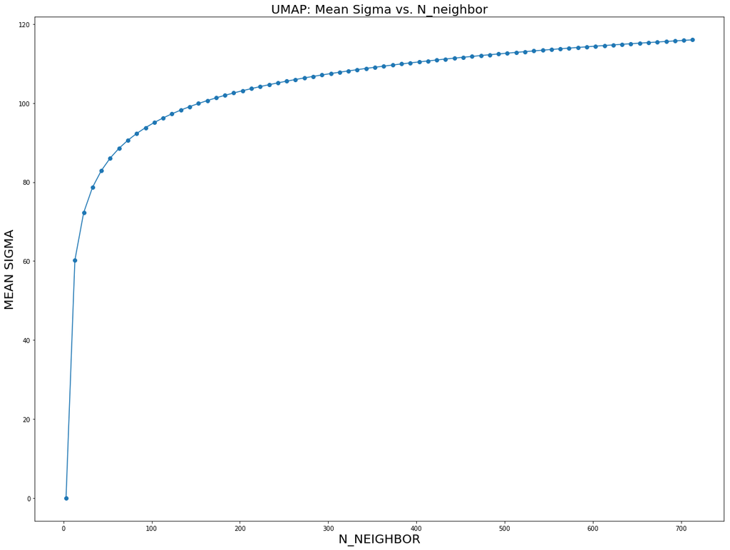

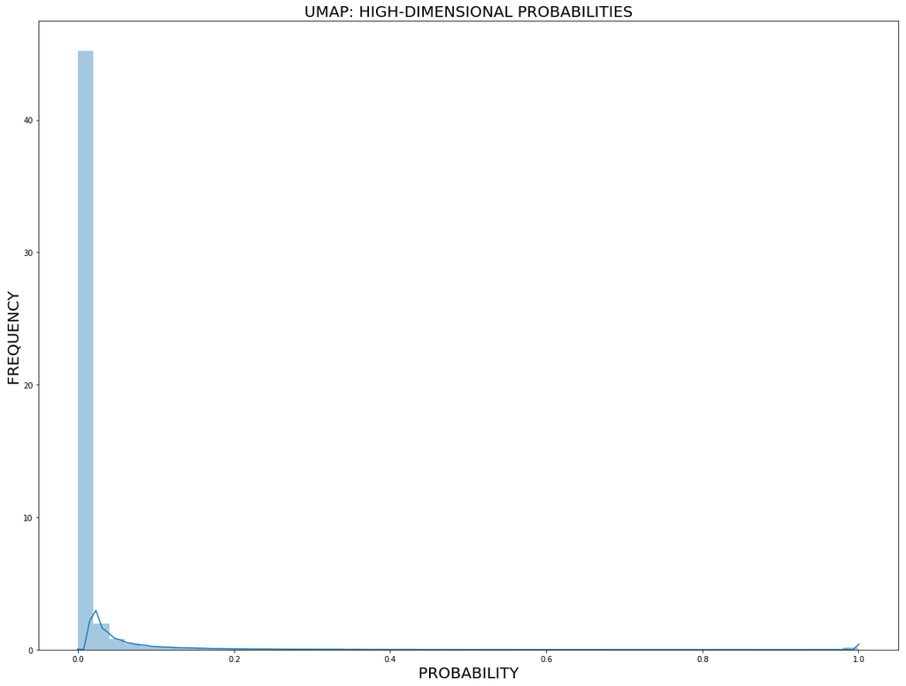

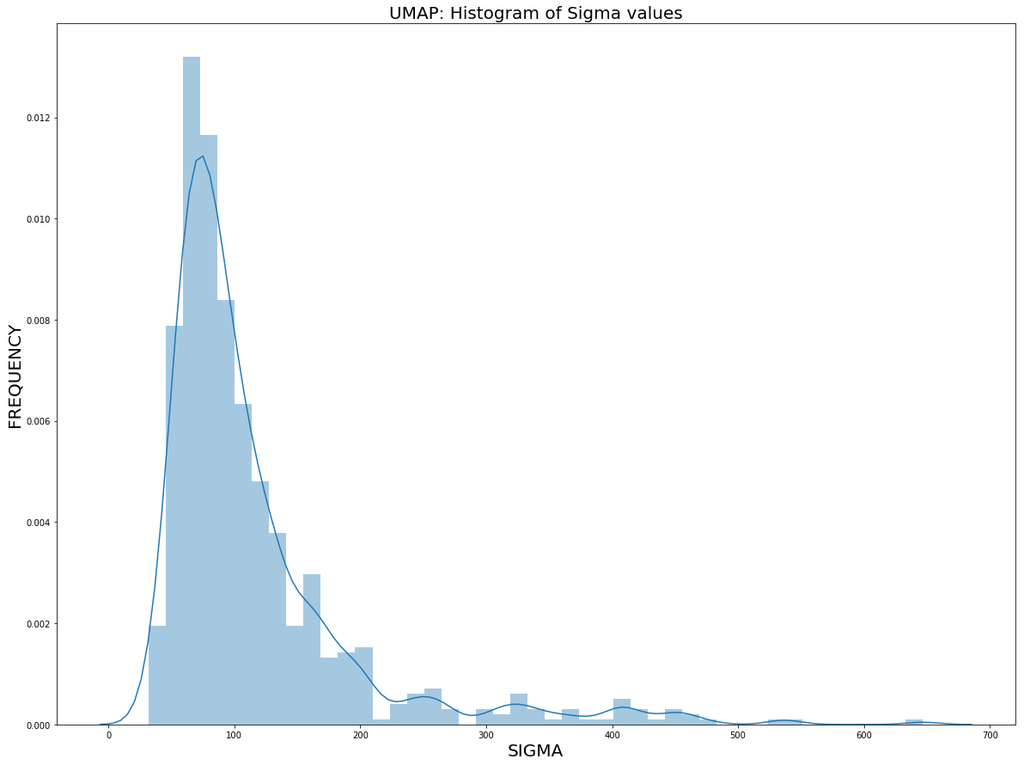

```python
import numpy as np
import pandas as pd
import seaborn as sns
import matplotlib.pyplot as plt
from sklearn.metrics.pairwise import euclidean_distances


dist = np.square(euclidean_distances(X_train, X_train))
rho = [sorted(dist[i])[1] for i in range(dist.shape[0])]

plt.figure(figsize=(20,15))
sns.distplot(dist.reshape(-1,1))
plt.title("HISTOGRAM OF EUCLIDEAN DISTANCES", fontsize = 20)
plt.xlabel("EUCLIDEAN DISTANCE", fontsize = 20); plt.ylabel("FREQUENCY", fontsize = 20)
plt.show()

def prob_high_dim(sigma, dist_row):
    d = dist[dist_row] - rho[dist_row]
    d[d < 0] = 0
    return np.exp(- d / sigma)

def k(prob):
    return np.power(2, np.sum(prob))

def sigma_binary_search(k_of_sigma, fixed_k):
    sigma_lower_limit = 0; sigma_upper_limit = 1000
    for i in range(20):
        approx_sigma = (sigma_lower_limit + sigma_upper_limit) / 2
        if k_of_sigma(approx_sigma) < fixed_k:
            sigma_lower_limit = approx_sigma
        else:
            sigma_upper_limit = approx_sigma
        if np.abs(fixed_k - k_of_sigma(approx_sigma)) <= 1e-5:
            break
    return approx_sigma

my_n_neighbor = []; my_sigma_umap = []
for N_NEIGHBOR in range(3, X_train.shape[0], 10):

    prob = np.zeros((n,n)); sigma_array = []
    for dist_row in range(n):
        func = lambda sigma: k(prob_high_dim(sigma, dist_row))
        binary_search_result = sigma_binary_search(func, N_NEIGHBOR)
        prob[dist_row] = prob_high_dim(binary_search_result, dist_row)
        sigma_array.append(binary_search_result)

    print("N_neighbor = {0}, Mean Sigma = {1}".format(N_NEIGHBOR, np.mean(sigma_array)))

    my_n_neighbor.append(N_NEIGHBOR)
    my_sigma_umap.append(np.mean(sigma_array))

plt.figure(figsize=(20,15))
plt.plot(my_n_neighbor, my_sigma_umap, '-o')
plt.title("UMAP: Mean Sigma vs. N_neighbor", fontsize = 20)
plt.xlabel("N_NEIGHBOR", fontsize = 20); plt.ylabel("MEAN SIGMA", fontsize = 20)
plt.show()

plt.figure(figsize=(20,15))
sns.distplot(prob.reshape(-1,1))
plt.title("UMAP: HIGH-DIMENSIONAL PROBABILITIES", fontsize = 20)
plt.xlabel("PROBABILITY", fontsize = 20); plt.ylabel("FREQUENCY", fontsize = 20)
plt.show()

plt.figure(figsize=(20,15))
sns.distplot(sigma_array)
plt.title("UMAP: Histogram of Sigma values", fontsize = 20)
plt.xlabel("SIGMA", fontsize = 20)
plt.ylabel("FREQUENCY", fontsize = 20)
plt.show()
```

Please note that the high-dimensional probability values became much larger for UMAP and some small peak around 1 is quite visible.

We can see that $\sigma$ depends on n_neighbors in a very different way for UMAP compared to tSNE. It does not go to infinity that fast compared to tSNE. This implies that **as Perplexity / N_neighbors approaches the sample size N, for UMAP $\sigma$ remains finite while for tSNE $\sigma$ goes to infinity**. We can approximate $\sigma(\rm{n\_neighbor})$ dependence with the following simple expression:

$$\sigma(\rm{n\_neighbor})\approx -\frac{1}{\displaystyle\ln\left(\frac{\log_2(\rm{n\_neighbor})}{N}\right)}$$

```
[136.0680298   24.09538417]
```

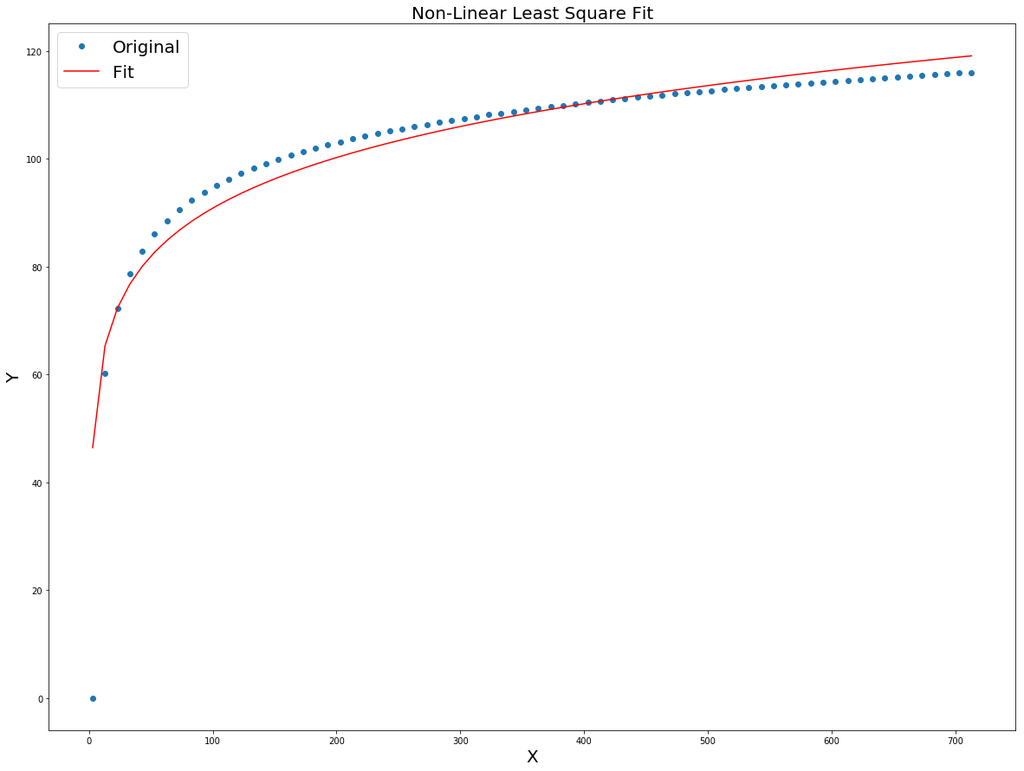

```python
from scipy import optimize
import matplotlib.pyplot as plt
import numpy as np

N = X_train.shape[0]

n_neighbor = np.array(my_n_neighbor)
sigma_exact = np.array(my_sigma_umap)

sigma = lambda n_neighbor, a, b: - a / np.log(b * np.log2(n_neighbor) / N)

p , _ = optimize.curve_fit(sigma, n_neighbor, sigma_exact)
print(p)

plt.figure(figsize=(20,15))
plt.plot(n_neighbor, sigma_exact, "o")
plt.plot(n_neighbor, sigma(n_neighbor, p[0], p[1]), c = "red")
plt.title("Non-Linear Least Square Fit", fontsize = 20)
plt.gca().legend(('Original', 'Fit'), fontsize = 20)
plt.xlabel("X", fontsize = 20); plt.ylabel("Y", fontsize = 20)
plt.show()
```

Let us compare how Perplexity and N_neighbors hyperparameters behave for tSNE and UMAP, respectively, for the same data set where the Euclidean distances are fixed. For this purpose we need to realize that the computed sigma for UMAP is not directly comparable with the computed sigma for tSNE since we have $2\sigma^2$ in the denominator of the power of the exponent in the equation for high-dimensional probabilities, while it is just $\sigma$ in the corresponding denominator for UMAP. Therefore, we need to square all the obtained tSNE sigmas and multiply them by two.

```python
my_sigma_tSNE_mod = [2*(i**2) for i in my_sigma_tSNE]
```

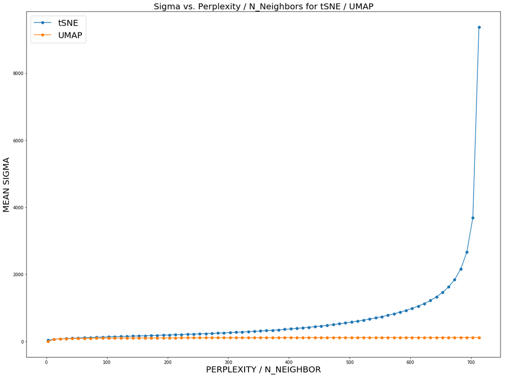

```python
plt.figure(figsize=(20, 15))

plt.plot(my_perp, my_sigma_tSNE_mod, '-o')
plt.plot(my_n_neighbor, my_sigma_umap, '-o')

plt.gca().legend(('tSNE','UMAP'), fontsize = 20)
plt.title("Sigma vs. Perplexity / N_Neighbors for tSNE / UMAP", fontsize = 20)
plt.xlabel("PERPLEXITY / N_NEIGHBOR", fontsize = 20); plt.ylabel("MEAN SIGMA", fontsize = 20)
plt.show()
```

UMAP's mean sigma does not change much with n_neighbor and reaches much smaller values than tSNE's mean sigma, so really hard to compare them as they are not on the same sacel, log-transform did not improve the view, let us restrict the x-axis in order to enlarge and resolve the behavior of UMAP's mean sigma.

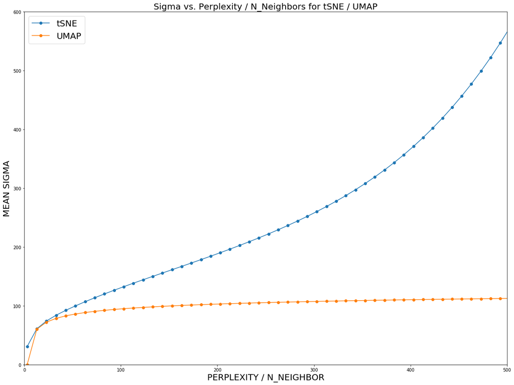

```python
plt.figure(figsize=(20, 15))

plt.plot(my_perp, my_sigma_tSNE_mod, '-o')
plt.plot(my_n_neighbor, my_sigma_umap, '-o')

plt.gca().legend(('tSNE','UMAP'), fontsize = 20)
plt.title("Sigma vs. Perplexity / N_Neighbors for tSNE / UMAP", fontsize = 20)
plt.xlabel("PERPLEXITY / N_NEIGHBOR", fontsize = 20); plt.ylabel("MEAN SIGMA", fontsize = 20)
plt.ylim(0,600); plt.xlim(0,500)
plt.show()
```

Again we can see that for UMAP the dependence $\sigma(\rm{n\_neighbor})$ is logarithmic and therefore very slow while for tSNE $\sigma(\rm{Perplexity})$ very quickly goes to infinity when Perplexity approaches the sample size N. Therefore **tSNE is much more sensitive to the Perplexity hyperparameter than UMAP towards N_neighbors hyperparameter**.

```
(3023, 2)
(3023,)
```

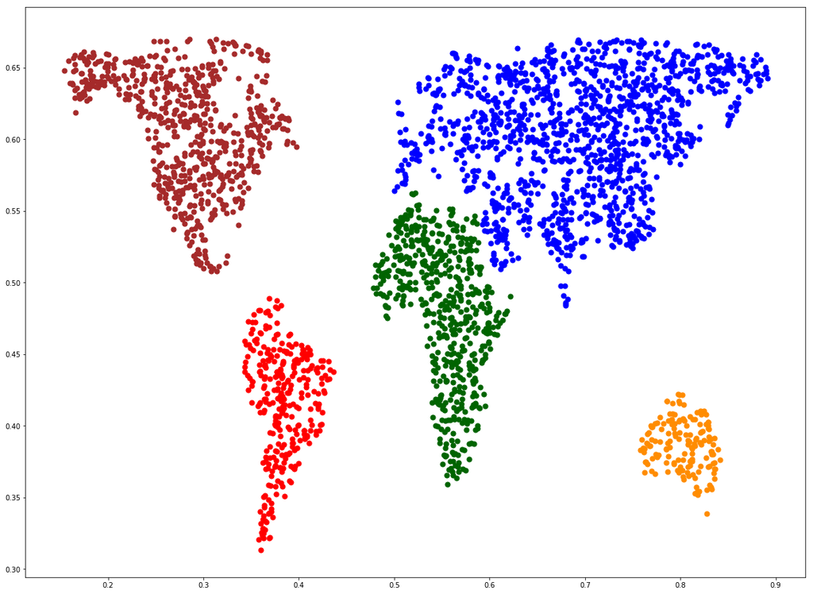

```python
import cartopy
import numpy as np
import cartopy.crs as ccrs
import matplotlib.pyplot as plt
import cartopy.feature as cfeature
from skimage.io import imread
import cartopy.io.shapereader as shpreader

shapename = 'admin_0_countries'
countries_shp = shpreader.natural_earth(resolution='110m',
                                        category='cultural', name=shapename)

plt.figure(figsize = (20, 15))
ax = plt.axes(projection=ccrs.Miller())
ax.outline_patch.set_visible(False)
ax.set_extent([-180, 180, -50, 70])
for country in shpreader.Reader(countries_shp).records():
    #print(country.attributes['NAME_LONG'])
    if country.attributes['NAME_LONG'] in ['United States','Canada', 'Mexico']:
        ax.add_geometries(country.geometry, ccrs.Miller(),
                          label=country.attributes['NAME_LONG'], color = 'black')
        plt.savefig('NorthAmerica.png')
plt.close()

plt.figure(figsize = (20, 15))
ax = plt.axes(projection=ccrs.Miller())
ax.outline_patch.set_visible(False)
ax.set_extent([-180, 180, -50, 70])
for country in shpreader.Reader(countries_shp).records():
    if country.attributes['NAME_LONG'] in ['Brazil','Argentina', 'Peru', 'Uruguay', 'Venezuela',
                                           'Columbia', 'Bolivia', 'Colombia', 'Ecuador', 'Paraguay']:
        ax.add_geometries(country.geometry, ccrs.Miller(),
                          label=country.attributes['NAME_LONG'], color = 'black')
        plt.savefig('SouthAmerica.png')
plt.close()

plt.figure(figsize = (20, 15))
ax = plt.axes(projection=ccrs.Miller())
ax.outline_patch.set_visible(False)
ax.set_extent([-180, 180, -50, 70])
for country in shpreader.Reader(countries_shp).records():
    if country.attributes['NAME_LONG'] in ['Australia']:
        ax.add_geometries(country.geometry, ccrs.Miller(),
                          label=country.attributes['NAME_LONG'], color = 'black')
        plt.savefig('Australia.png')
plt.close()


plt.figure(figsize = (20, 15))
ax = plt.axes(projection=ccrs.Miller())
ax.outline_patch.set_visible(False)
ax.set_extent([-180, 180, -50, 70])
for country in shpreader.Reader(countries_shp).records():
    if country.attributes['NAME_LONG'] in ['Russian Federation', 'China', 'India', 'Kazakhstan', 'Mongolia',
                                          'France', 'Germany', 'Spain', 'Ukraine', 'Turkey', 'Sweden',
                                           'Finland', 'Denmark', 'Greece', 'Poland', 'Belarus', 'Norway',
                                           'Italy', 'Iran', 'Pakistan', 'Afganistan', 'Iraq', 'Bulgaria',
                                           'Romania', 'Turkmenistan', 'Uzbekistan' 'Austria', 'Ireland',
                                           'United Kingdom', 'Saudi Arabia', 'Hungary']:
        ax.add_geometries(country.geometry, ccrs.Miller(),
                          label=country.attributes['NAME_LONG'], color = 'black')
        plt.savefig('Eurasia.png')
plt.close()


plt.figure(figsize = (20, 15))
ax = plt.axes(projection=ccrs.Miller())
ax.outline_patch.set_visible(False)
ax.set_extent([-180, 180, -50, 70])
for country in shpreader.Reader(countries_shp).records():
    if country.attributes['NAME_LONG'] in ['Libya', 'Algeria', 'Niger', 'Marocco', 'Egypt', 'Sudan', 'Chad',
                                           'Democratic Republic of the Congo', 'Somalia', 'Kenya', 'Ethiopia',
                                           'The Gambia', 'Nigeria', 'Cameroon', 'Ghana', 'Guinea', 'Guinea-Bissau',
                                           'Liberia', 'Sierra Leone', 'Burkina Faso', 'Central African Republic',
                                           'Republic of the Congo', 'Gabon', 'Equatorial Guinea', 'Zambia',
                                           'Malawi', 'Mozambique', 'Angola', 'Burundi', 'South Africa',
                                           'South Sudan', 'Somaliland', 'Uganda', 'Rwanda', 'Zimbabwe', 'Tanzania',
                                           'Botswana', 'Namibia', 'Senegal', 'Mali', 'Mauritania', 'Benin',
                                           'Nigeria', 'Cameroon']:
        ax.add_geometries(country.geometry, ccrs.Miller(),
                          label=country.attributes['NAME_LONG'], color = 'black')
        plt.savefig('Africa.png')
plt.close()


rng = np.random.RandomState(123)
plt.figure(figsize = (20,15))

N_NorthAmerica = 10000
data_NorthAmerica = imread('NorthAmerica.png')[::-1, :, 0].T
X_NorthAmerica = rng.rand(4 * N_NorthAmerica, 2)
i, j = (X_NorthAmerica * data_NorthAmerica.shape).astype(int).T
X_NorthAmerica = X_NorthAmerica[data_NorthAmerica[i, j] < 1]
X_NorthAmerica = X_NorthAmerica[X_NorthAmerica[:, 1]<0.67]
y_NorthAmerica = np.array(['brown']*X_NorthAmerica.shape[0])
plt.scatter(X_NorthAmerica[:, 0], X_NorthAmerica[:, 1], c = 'brown', s = 50)

N_SouthAmerica = 10000
data_SouthAmerica = imread('SouthAmerica.png')[::-1, :, 0].T
X_SouthAmerica = rng.rand(4 * N_SouthAmerica, 2)
i, j = (X_SouthAmerica * data_SouthAmerica.shape).astype(int).T
X_SouthAmerica = X_SouthAmerica[data_SouthAmerica[i, j] < 1]
y_SouthAmerica = np.array(['red']*X_SouthAmerica.shape[0])
plt.scatter(X_SouthAmerica[:, 0], X_SouthAmerica[:, 1], c = 'red', s = 50)

N_Australia = 10000
data_Australia = imread('Australia.png')[::-1, :, 0].T
X_Australia = rng.rand(4 * N_Australia, 2)
i, j = (X_Australia * data_Australia.shape).astype(int).T
X_Australia = X_Australia[data_Australia[i, j] < 1]
y_Australia = np.array(['darkorange']*X_Australia.shape[0])
plt.scatter(X_Australia[:, 0], X_Australia[:, 1], c = 'darkorange', s = 50)

N_Eurasia = 10000
data_Eurasia = imread('Eurasia.png')[::-1, :, 0].T
X_Eurasia = rng.rand(4 * N_Eurasia, 2)
i, j = (X_Eurasia * data_Eurasia.shape).astype(int).T
X_Eurasia = X_Eurasia[data_Eurasia[i, j] < 1]
X_Eurasia = X_Eurasia[X_Eurasia[:, 0]>0.5]
X_Eurasia = X_Eurasia[X_Eurasia[:, 1]<0.67]
y_Eurasia = np.array(['blue']*X_Eurasia.shape[0])
plt.scatter(X_Eurasia[:, 0], X_Eurasia[:, 1], c = 'blue', s = 50)

N_Africa = 10000
data_Africa = imread('Africa.png')[::-1, :, 0].T
X_Africa = rng.rand(4 * N_Africa, 2)
i, j = (X_Africa * data_Africa.shape).astype(int).T
X_Africa = X_Africa[data_Africa[i, j] < 1]
y_Africa = np.array(['darkgreen']*X_Africa.shape[0])
plt.scatter(X_Africa[:, 0], X_Africa[:, 1], c = 'darkgreen', s = 50)

X = np.vstack((X_NorthAmerica, X_SouthAmerica, X_Australia, X_Eurasia, X_Africa))
y = np.concatenate((y_NorthAmerica, y_SouthAmerica, y_Australia, y_Eurasia, y_Africa))
print(X.shape)
print(y.shape)

plt.show()
```

```
This data set contains 3023 samples

Dimensions of the  data set:
(3023, 2) (3023,)
```

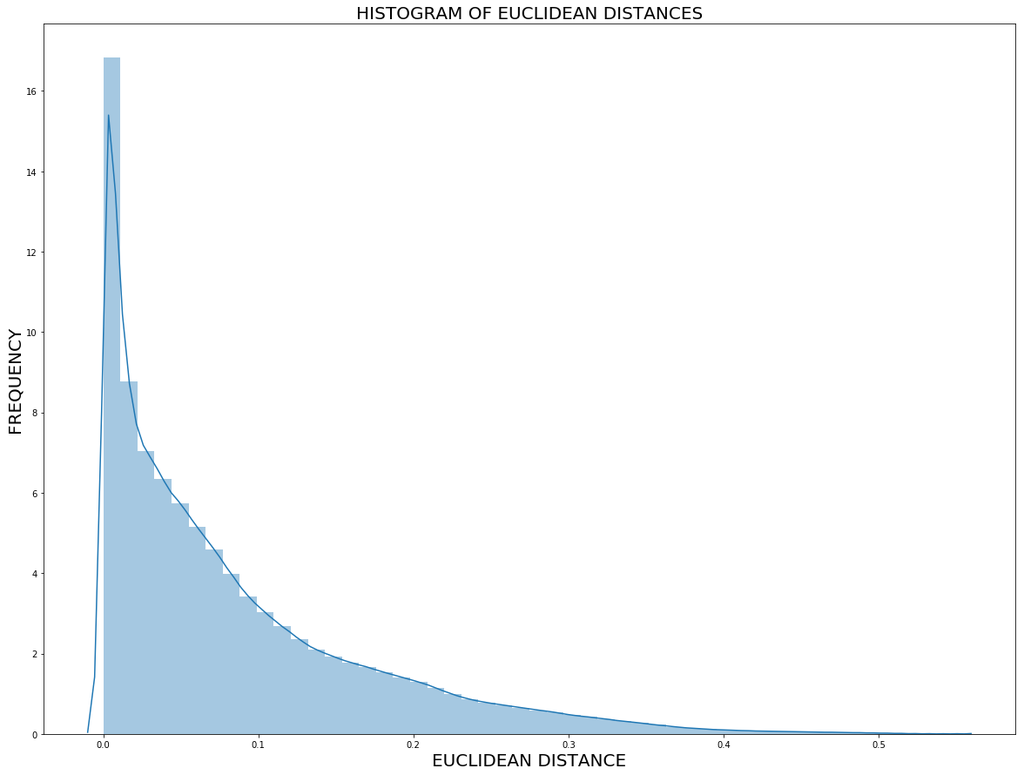

```
Perplexity = 3, Mean Sigma = 0.0020824360445245308
Perplexity = 203, Mean Sigma = 0.026983336190928145
Perplexity = 403, Mean Sigma = 0.04243961123492676
Perplexity = 603, Mean Sigma = 0.05657405518870302
Perplexity = 803, Mean Sigma = 0.07055265557241487
Perplexity = 1003, Mean Sigma = 0.08290341623642568
Perplexity = 1203, Mean Sigma = 0.09496204907476921
Perplexity = 1403, Mean Sigma = 0.1074566653419164
Perplexity = 1603, Mean Sigma = 0.12099297284054669
Perplexity = 1803, Mean Sigma = 0.13608960887670438
Perplexity = 2003, Mean Sigma = 0.1530494273517292
Perplexity = 2203, Mean Sigma = 0.17244280311314428
Perplexity = 2403, Mean Sigma = 0.19591208763008988
Perplexity = 2603, Mean Sigma = 0.22778556790921295
Perplexity = 2803, Mean Sigma = 0.28223238991381827
Perplexity = 3003, Mean Sigma = 0.5550955527277526
```

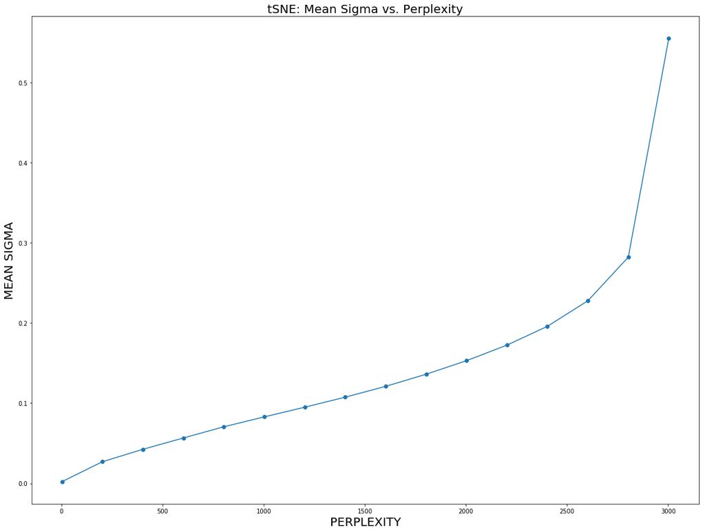

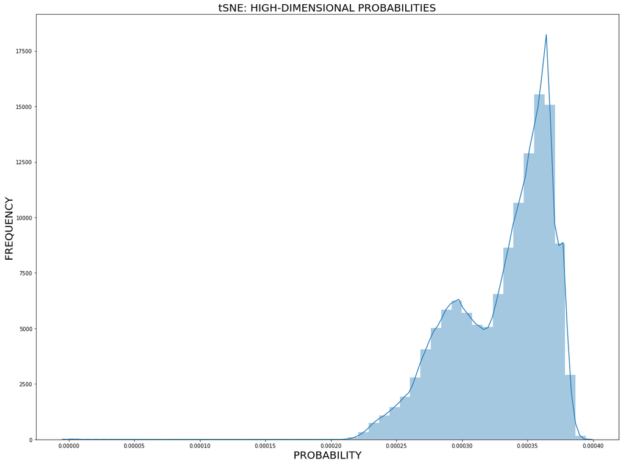

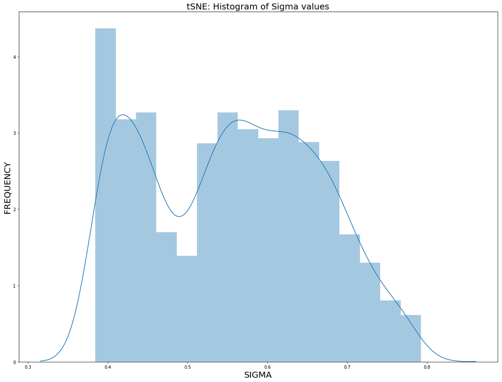

```python
import numpy as np
import pandas as pd
import seaborn as sns
import matplotlib.pyplot as plt
from sklearn.metrics.pairwise import euclidean_distances

import warnings
warnings.filterwarnings("ignore")

X_train = X
n = X_train.shape[0]
print("\nThis data set contains " + str(n) + " samples")
y_train = y
print("\nDimensions of the  data set: ")
print(X_train.shape, y_train.shape)

dist = np.square(euclidean_distances(X_train, X_train))

plt.figure(figsize = (20,15))
sns.distplot(dist.reshape(-1,1))
plt.title("HISTOGRAM OF EUCLIDEAN DISTANCES", fontsize = 20)
plt.xlabel("EUCLIDEAN DISTANCE", fontsize = 20); plt.ylabel("FREQUENCY", fontsize = 20)
plt.show()

def prob_high_dim(sigma, dist_row):
    exp_distance = np.exp(-dist[dist_row] / (2*sigma**2))
    exp_distance[dist_row] = 0
    prob_not_symmetr = exp_distance / np.sum(exp_distance)
    return prob_not_symmetr

def perplexity(prob):
    return np.power(2, -np.sum([p*np.log2(p) for p in prob if p!=0]))

def sigma_binary_search(perp_of_sigma, fixed_perplexity):
    sigma_lower_limit = 0; sigma_upper_limit = 1000
    for i in range(20):
        approx_sigma = (sigma_lower_limit + sigma_upper_limit) / 2
        if perp_of_sigma(approx_sigma) < fixed_perplexity:
            sigma_lower_limit = approx_sigma
        else:
            sigma_upper_limit = approx_sigma
        if np.abs(fixed_perplexity - perp_of_sigma(approx_sigma)) <= 1e-5:
            break
    return approx_sigma

my_perp = []; my_sigma_tSNE = []
for PERPLEXITY in range(3, X_train.shape[0], 200):

    prob = np.zeros((n,n)); sigma_array = []
    for dist_row in range(n):
        func = lambda sigma: perplexity(prob_high_dim(sigma, dist_row))
        binary_search_result = sigma_binary_search(func, PERPLEXITY)
        prob[dist_row] = prob_high_dim(binary_search_result, dist_row)
        sigma_array.append(binary_search_result)

    print("Perplexity = {0}, Mean Sigma = {1}".format(PERPLEXITY, np.mean(sigma_array)))

    my_perp.append(PERPLEXITY)
    my_sigma_tSNE.append(np.mean(sigma_array))

plt.figure(figsize = (20,15))
plt.plot(my_perp, my_sigma_tSNE, '-o')
plt.title("tSNE: Mean Sigma vs. Perplexity", fontsize = 20)
plt.xlabel("PERPLEXITY", fontsize = 20); plt.ylabel("MEAN SIGMA", fontsize = 20)
plt.show()

plt.figure(figsize = (20,15))
sns.distplot(prob.reshape(-1,1))
plt.title("tSNE: HIGH-DIMENSIONAL PROBABILITIES", fontsize = 20)
plt.xlabel("PROBABILITY", fontsize = 20); plt.ylabel("FREQUENCY", fontsize = 20)
plt.show()

plt.figure(figsize = (20,15))
sns.distplot(sigma_array)
plt.title("tSNE: Histogram of Sigma values", fontsize = 20)
plt.xlabel("SIGMA", fontsize = 20)
plt.ylabel("FREQUENCY", fontsize = 20)
plt.show()
```